# Evaluating Auxiliary Variables in EMA: Step-by-Step Tutorial

Stefan Schneider

# 1 Overview

This notebook implements **Step 2** of the *EMAuxiliary Workflow*: evaluating candidate auxiliary variables in EMA data.  
Auxiliary variables help make the missing-at-random (MAR) assumption more plausible and can reduce bias due to prompt nonresponse.

**What this notebook does** 1. Data prep for auxiliary variable evaluation: Classify each auxiliary as within-, between-, or mixed-level variables (based on ICC). Decompose and standardize variables into within- and between-person parts.  
3. Estimate multilevel logistic models predicting missingness 4. Compute within- and between-level correlations between auxiliary variables and focal variables. 5. Generate a detailed summary table to evaluate auxiliaries. 6. Create a heatmap to visually summarize auxiliary variable strength.

**Output**  
Produces interactive and static tables summarizing each auxiliary’s predictive utility and conceptual relevance.  
These results guide the selection of auxiliaries to include in Step 3 (*Modeling with EMAuxiliary*).

For background and installation instructions, see the [README](https://github.com/schneids111/EMAuxiliary-Workflow).

# 2 Introduction

This tutorial guides you step-by-step through the evaluation of **auxiliary variables** in Ecological Momentary Assessment (EMA) data.  
Auxiliary variables can improve the plausibility of missing-at-random (MAR) assumptions and reduce bias due to nonresponse.

Each section explains **what to do**, **why it matters**, and **how to interpret the results**.

> **Packages required:**  
> Install these before running:  
> `install.packages(c("lme4", "broom.mixed", "dplyr", "tidyr", "gt", "DT", "patchwork"))`

## 2.1 Step 1: Load Your EMA Dataset

**What to do:** Replace the file path below with your own dataset.  
**Your data must include:** - an **ID variable** identifying individuals  
- a **missingness variable** (1 = missing prompt, 0 = completed prompt)  
- one or more **candidate auxiliary variables**  
- one or more **focal variables** from your model of interest

### 2.1.1 Optional: Try the Example Dataset (for testing only)

> **If you don’t yet have your data ready**, uncomment and run this section to create a tiny toy dataset. It includes a **pure within** variable (`day_of_study`) and a **pure between** variable (`age`). Remember to **comment this back out** when you switch to your own data.

```r
set.seed(123)
ema_df <- data.frame(
  id = rep(1:6, each = 5),
  time_of_day = runif(30, 6, 22),
  day_of_study = rep(1:5, times = 6),
  weekend = sample(0:1, 30, replace = TRUE),
  negative_affect = rnorm(30),
  physical_activity = rnorm(30),
  sedentary_behavior = rnorm(30),
  completion_time = runif(30, 2, 8),
  prompt_delay = runif(30, 0, 2)
)
ema_df$age <- rep(sample(45:75, 6, replace = TRUE), each = 5)

# Small missingness model signal: longer completion_time and weekends increase missingness
linpred <- (ema_df$completion_time - mean(ema_df$completion_time)) * 0.3 +
           0.25 * (ema_df$weekend - mean(ema_df$weekend))
ema_df$missed_prompt <- rbinom(30, 1, plogis(linpred))

head(ema_df)
```

## 2.2 Step 2: Define Your Variables

**What to do:** Insert the column names from your dataset.  
- `aux_vars`: candidate auxiliaries to screen  
- `focal_vars`: outcome/predictors from your main model (used for interpretive correlations)  
- `id_var`: person identifier  
- `missing_var`: prompt-level missingness indicator (1 = missed prompt)

```r
# 🔄 EDIT THESE NAMES to match your dataset
aux_vars <- c(
 "std_physact1",
 "std_negaff",
 "BMI",
 "male",
 "age",
  "lag_missing",
 "ACC_NSteps",
 "lag_response_time",
 "lag_delay",
 "lag_physact2",
 "lag_posaff",
 "lag_negaff_ce",
 "lag_physact1_ce",
 "weekend",
 "day_n",
 "trigger_hr_ce",
 "trigger_hr_sin"
 )

# Focal variables from your substantive model (e.g., outcome and/or predictors)
focal_vars <- c("negaff", "physact1")

# Key identifiers
id_var <- "idn"          # person identifier in your dataset
missing_var <- "missing" # prompt-level missingness (1 = missing, 0 = completed)
```

## 2.3 Step 3a: Data Readiness Check

**What this does:** Ensures all required names exist in the dataset.  
**Why it matters:** Prevents cryptic errors later (e.g., misspellings or missing columns). **If you see warnings:** double-check your variable names

```r
# 1) Verify dataset
if (!exists("ema_df")) {
  stop("❌ Dataset 'ema_df' not found. Please load or create it in Step 1 before proceeding.")
}
ema_df <- as.data.frame(ema_df)

# 2) Verify ID and missingness
if (!(id_var %in% names(ema_df))) {
  stop(paste0("❌ The ID variable '", id_var, "' was not found in ema_df."))
}
if (!(missing_var %in% names(ema_df))) {
  stop(paste0("❌ The missingness variable '", missing_var, "' was not found in ema_df."))
}

# 3) Check auxiliaries
missing_aux <- setdiff(aux_vars, names(ema_df))
if (length(missing_aux) > 0) {
  msg <- paste0("⚠️ The following auxiliary variable(s) were not found in ema_df and will be skipped: ",
                paste(missing_aux, collapse = ", "))
  cat("\n", msg, "\n")
  warning(msg, call. = FALSE)
  aux_vars <- intersect(aux_vars, names(ema_df))
}

# 4) Check focal variables
missing_focal <- setdiff(focal_vars, names(ema_df))
if (length(missing_focal) > 0) {
  msg <- paste0("⚠️ The following focal variable(s) were not found in ema_df and will be skipped: ",
                paste(missing_focal, collapse = ", "))
  cat("\n", msg, "\n")
  warning(msg, call. = FALSE)
  focal_vars <- intersect(focal_vars, names(ema_df))
}

# 5) Summary message
message("✅ Data readiness check completed successfully.")
```

```
## ✅ Data readiness check completed successfully.
```

```r
message("  • Dataset dimensions: ", nrow(ema_df), " rows × ", ncol(ema_df), " columns")
```

```
##   • Dataset dimensions: 6335 rows × 21 columns
```

```r
message("  • ID variable: ", id_var)
```

```
##   • ID variable: idn
```

```r
message("  • Missingness variable: ", missing_var)
```

```
##   • Missingness variable: missing
```

```r
message("  • Auxiliary variables (", length(aux_vars), "): ", paste(aux_vars, collapse = ", "))
```

```
##   • Auxiliary variables (17): std_physact1, std_negaff, BMI, male, age, lag_missing, ACC_NSteps, lag_response_time, lag_delay, lag_physact2, lag_posaff, lag_negaff_ce, lag_physact1_ce, weekend, day_n, trigger_hr_ce, trigger_hr_sin
```

```r
message("  • Focal variables (", length(focal_vars), "): ", paste(focal_vars, collapse = ", "))
```

```
##   • Focal variables (2): negaff, physact1
```

## 2.4 Step 3b: Compute ICCs for Each Auxiliary

**What this does:** Quantifies each auxiliary’s between-person proportion of variance.  
**Why it matters:** We classify auxiliaries as `pure_within` (ICC < .05), `pure_between` (ICC > .95), or `mixed`. **Note:** Ordered factors (ordered categorical variables) should be recoded as numeric. Nominal (unordered categorical variables) should be recoded as into a series of binary numeric variables.

```r
icc_df <- data.frame()

for (var in aux_vars) {
  if (!var %in% names(ema_df)) next

  df_icc <- ema_df %>%
    dplyr::group_by(!!rlang::sym(id_var)) %>%
    dplyr::summarize(
      grp_mean = mean(.data[[var]], na.rm = TRUE),
      grp_var  = var(.data[[var]],  na.rm = TRUE)
    ) %>%
    dplyr::ungroup()

  var_between <- var(df_icc$grp_mean, na.rm = TRUE)
  var_within  <- mean(df_icc$grp_var, na.rm = TRUE)
  icc_val     <- var_between / (var_between + var_within)

  icc_df <- rbind(icc_df, data.frame(variable = var, ICC = icc_val))
}

ema_icc <- icc_df %>%
  dplyr::mutate(
    ICC = round(ICC, 3),
    classification = dplyr::case_when(
      ICC > .95 ~ "pure_between",
      ICC < .05 ~ "pure_within",
      TRUE      ~ "mixed"
    )
  )

ema_icc
```

```
##             variable   ICC classification
## 1       std_physact1 1.000   pure_between
## 2         std_negaff 1.000   pure_between
## 3                BMI 1.000   pure_between
## 4               male 1.000   pure_between
## 5                age 1.000   pure_between
## 6        lag_missing 0.229          mixed
## 7         ACC_NSteps 0.072          mixed
## 8  lag_response_time 0.366          mixed
## 9          lag_delay 0.196          mixed
## 10      lag_physact2 0.257          mixed
## 11        lag_posaff 0.642          mixed
## 12     lag_negaff_ce 0.000    pure_within
## 13   lag_physact1_ce 0.000    pure_within
## 14           weekend 0.000    pure_within
## 15             day_n 0.000    pure_within
## 16     trigger_hr_ce 0.003    pure_within
## 17    trigger_hr_sin 0.002    pure_within
```

## 2.5 Step 4: Center and Standardize Auxiliaries

**What this does:** Splits each auxiliary into within-person (WP) and between-person (PM) parts and standardizes them.  
**Why it matters:** Multilevel models need correctly separated components to avoid conflating within- and between-person effects.

```r
safe_sd <- function(x) if (all(is.na(x))) NA_real_ else sd(x, na.rm = TRUE)

for (var in aux_vars) {
  # Create person-mean and within-person deviations
  ema_df <- ema_df %>%
    dplyr::group_by(!!rlang::sym(id_var)) %>%
    dplyr::mutate(
      !!rlang::sym(paste0(var, "_PM")) := mean(.data[[var]], na.rm = TRUE),
      !!rlang::sym(paste0(var, "_WP")) := .data[[var]] - mean(.data[[var]], na.rm = TRUE)
    ) %>%
    dplyr::ungroup()

  # Standardize safely (leave NA when variance is zero)
  wp <- ema_df[[paste0(var, "_WP")]]
  pm <- ema_df[[paste0(var, "_PM")]]

  sd_wp <- safe_sd(wp)
  sd_pm <- safe_sd(pm)

  ema_df[[paste0(var, "_WP_z")]] <- if (!is.na(sd_wp) && sd_wp > 0) as.numeric(scale(wp)) else rep(NA_real_, nrow(ema_df))
  ema_df[[paste0(var, "_PM_z")]] <- if (!is.na(sd_pm) && sd_pm > 0) as.numeric(scale(pm)) else rep(NA_real_, nrow(ema_df))
}
```

## 2.6 Step 5: Predict Missingness (Multilevel Logistic Models)

**What this does:** For each auxiliary, estimates how strongly it predicts missingness at WP and/or PM level.  
**This is only for internal estimation only.** **Results are shown in Step 7.**

## 2.7 Step 6: Correlate Auxiliaries with Focal Variables

**What this does:** Computes signed **within-** and **between-person** correlations of each auxiliary with each focal variable.  
**This is only for internal estimation only.** **Results are shown in Step 7.**

## 2.8 Step 7: Interactive Detailed Table

**What this shows:** Each auxiliary variable appears once per level (within and/or between). Pure **within-person** variables appear only with Level = “within.” Pure **between-person** variables appear only with Level = “between.” **Mixed** variables appear twice, once per level. Columns show the variable’s association with **missingness (OR)** and with each **focal variable (correlations r)**.

```r
# 1) Merge correlation and logistic results
detailed_df <- cor_results %>%
  dplyr::left_join(logit_results, by = c("variable", "level")) %>%
  dplyr::left_join(ema_icc, by = "variable")

# 2) Mask irrelevant level-components based on ICC classification
detailed_df <- detailed_df %>%
  dplyr::mutate(
    OR = dplyr::if_else(classification == "pure_within"  & level == "between", NA_real_, OR),
    OR = dplyr::if_else(classification == "pure_between" & level == "within",  NA_real_, OR),
    correlation = dplyr::if_else(classification == "pure_within"  & level == "between", NA_real_, correlation),
    correlation = dplyr::if_else(classification == "pure_between" & level == "within",  NA_real_, correlation)
  )

# 3) Pivot correlations so focal variables become side-by-side columns
wide_cor <- detailed_df %>%
  dplyr::select(variable, level, focal_var, correlation) %>%
  tidyr::pivot_wider(
    names_from = focal_var,
    values_from = correlation,
    names_glue = "{focal_var}_r"
  )

# 4) Merge ORs and keep only relevant info (no ICC/classification)
wide_combined <- wide_cor %>%
  dplyr::left_join(
    detailed_df %>%
      dplyr::select(variable, level, OR) %>%
      dplyr::distinct(),
    by = c("variable", "level")
  ) %>%
  dplyr::select(variable, level, OR, dplyr::everything()) %>%
  dplyr::mutate(
    OR  = round(OR, 3),
    dplyr::across(dplyr::matches("_r$"), ~ round(.x, 3))
  )

# 5) Drop level-rows where all numeric columns are NA
wide_combined <- wide_combined %>%
  dplyr::filter(rowSums(!is.na(dplyr::select(., where(is.numeric)))) > 0)

# 6) Tidy up labels and order
wide_combined <- wide_combined %>%
  dplyr::arrange(variable, dplyr::desc(level)) %>%
  dplyr::rename(
    `Auxiliary Variable` = variable,
    `Level` = level,
    `Missingness (OR)` = OR
  )

# 7) Display interactive datatable
DT::datatable(
  wide_combined,
  extensions = "Scroller",
  options = list(
    pageLength = 50,
    scrollX = TRUE,
    deferRender = TRUE,
    dom = 'tip',
    columnDefs = list(list(className = 'dt-center', targets = "_all"))
  ),
  caption = htmltools::tags$caption(
    style = 'caption-side: top; text-align: left;',
    htmltools::tags$strong("Detailed overview of auxiliary variables by level."),
    htmltools::tags$br(),
    "Each variable appears once per relevant level (within and/or between).",
    htmltools::tags$br(),
    "Columns show odds ratios (OR) for missingness and correlations (r) with each focal variable."
  )
)
```

|  | Auxiliary Variable | Level | Missingness (OR) | negaff_r | physact1_r |
| --- | --- | --- | --- | --- | --- |
| 1 | ACC_NSteps | within | 1.068 | 0.002 | 0.164 |
| 2 | ACC_NSteps | between | 1.077 | 0.102 | 0.2 |
| 3 | BMI | between | 1.075 | 0.043 | -0.178 |
| 4 | age | between | 0.68 | -0.144 | 0.076 |
| 5 | day_n | within | 1.159 | -0.046 | 0.022 |
| 6 | lag_delay | within | 1.109 | 0.006 | 0.025 |
| 7 | lag_delay | between | 1.623 | -0.105 | -0.058 |
| 8 | lag_missing | within | 1.337 | -0.004 | 0.06 |
| 9 | lag_missing | between | 3.136 | 0.104 | -0.067 |
| 10 | lag_negaff_ce | within | 1.03 | 0.27 | 0.019 |

[output cut: 13 more lines]

# 3 *Step 8: Visual Heatmap of Auxiliary Variable Strength**

**What this shows:** This heatmap summarizes all quantitative evidence about each auxiliary variable in a single, intuitive visual format. The heatmap highlights the **pattern and magnitude** of associations across:

- **Missingness prediction** (magnitude of odds ratios, blind for direction)
- **Correlations** with each focal variable (absolute correlations)

Each auxiliary variable appears with both **within-person** and **between-person** components whenever those levels exist: * Pure **within-person** auxiliaries show only *within* tiles * Pure **between-person** auxiliaries show only *between* tiles * **Mixed** auxiliaries show a full set of tiles at both levels

This visualization allows you to quickly evaluate which auxiliaries show meaningfully sized relationships—*and at which levels*. It supports empirically grounded decisions about which auxiliary variables to include in your model.

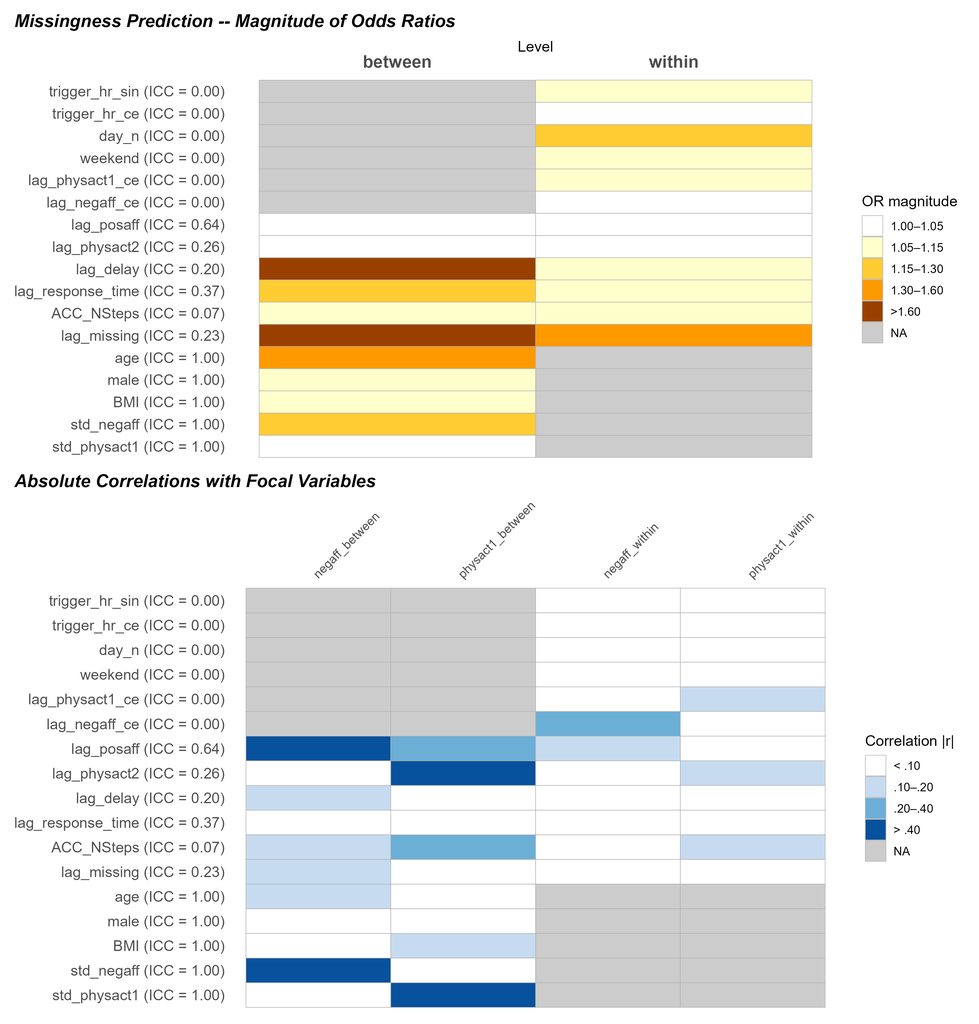

```r
## Step 8: Split-Panel Dual Heatmap (Missingness vs. Focal Variables)

# -------------------------------
# Helper: mask by classification
# -------------------------------

mask_by_classification <- function(df, class_df) {
  df %>%
    left_join(class_df %>% select(variable, classification), by = "variable") %>%
    mutate(
      value = case_when(
        classification == "pure_within"  & level == "between" ~ NA_real_,
        classification == "pure_between" & level == "within"  ~ NA_real_,
        TRUE                                                    ~ value
      )
    ) %>%
    select(-classification)
}

# -------------------------------
# 0. Common pieces: variables, labels
# -------------------------------

aux_vars_all <- ema_icc$variable

ema_icc <- ema_icc %>%
  mutate(
    icc_label = ifelse(
      is.na(ICC),
      paste0(variable, " (ICC = NA)"),
      paste0(variable, " (ICC = ", sprintf("%.2f", ICC), ")")
    )
  )

aux_order <- ema_icc$icc_label


# ============================================================
# PANEL 1 — Missingness (OR-metric heatmap)
# ============================================================

# Grid: variable × level
miss_grid <- expand.grid(
  variable = aux_vars_all,
  level    = c("within", "between"),
  stringsAsFactors = FALSE
)

# Convert OR to magnitude > 1 by flipping OR < 1
logit_or <- logit_results %>%
  mutate(
    OR_mag = exp(abs(log(OR)))   # always ≥ 1
  ) %>%
  select(variable, level, OR_mag)

miss_df <- miss_grid %>%
  left_join(logit_or, by = c("variable", "level")) %>%
  rename(value = OR_mag) %>%     # unify name for binning
  mask_by_classification(ema_icc) %>%
  left_join(ema_icc, by = "variable") %>%
  mutate(
    aux_label = factor(icc_label, levels = aux_order)
  )

# OR bins (your proposed interpretation)
miss_df <- miss_df %>%
  mutate(
    bin = case_when(
      is.na(value)        ~ "NA",
      value < 1.05        ~ "1.00–1.05",
      value < 1.15        ~ "1.05–1.15",
      value < 1.30        ~ "1.15–1.30",
      value < 1.60        ~ "1.30–1.60",
      value >= 1.60       ~ ">1.60"
    ),
    bin = factor(bin, levels = c("1.00–1.05","1.05–1.15","1.15–1.30","1.30–1.60",">1.60","NA"))
  )

# Gold palette
palette_miss <- c(
  "1.00–1.05" = "white",
  "1.05–1.15" = "#FFFFCC",
  "1.15–1.30" = "#FFCC33",
  "1.30–1.60" = "#FF9900",
  ">1.60"     = "#994000",
  "NA"        = "#CCCCCC"
)


p_missing <- ggplot(miss_df, aes(x = level, y = aux_label, fill = bin)) +
  geom_tile(color = "grey70") +
  scale_fill_manual(
    values = palette_miss,
    drop = FALSE,
    name   = "OR magnitude"
  ) +
  scale_x_discrete(position = "top") +
  labs(
    x = "Level",
    y = NULL,
    title = "Missingness Prediction -- Magnitude of Odds Ratios"
  ) +
  theme_minimal(base_size = 12) +
  theme(
    axis.text.x  = element_text(size = 14, face = "bold"),
    axis.text.y  = element_text(size = 12),
    panel.grid   = element_blank(),
    plot.title.position = "plot",
    plot.title   = element_text(face = "bold.italic")
  )


# ============================================================
# PANEL 2 — Correlations (r-metric heatmap)
# ============================================================

cor_grid <- expand.grid(
  variable  = aux_vars_all,
  level     = c("between", "within"),
  focal_var = focal_vars,
  stringsAsFactors = FALSE
)

corr_r <- cor_results %>%
  mutate(value = abs(correlation)) %>%
  select(variable, level, focal_var, value)

cor_df <- cor_grid %>%
  left_join(corr_r, by = c("variable","level","focal_var")) %>%
  mask_by_classification(ema_icc) %>%
  left_join(ema_icc, by = "variable") %>%
  mutate(
    aux_label = factor(icc_label, levels = aux_order),
    metric_raw = paste(focal_var, level, sep = "_")
  )

metric_levels <- c(
  paste0(focal_vars, "_between"),
  paste0(focal_vars, "_within")
)

cor_df <- cor_df %>%
  mutate(metric = factor(metric_raw, levels = metric_levels))

# r bins
cor_df <- cor_df %>%
  mutate(
    bin = case_when(
      is.na(value)       ~ "NA",
      value < .10        ~ "< .10",
      value < .20        ~ ".10–.20",
      value < .40        ~ ".20–.40",
      value >= .40       ~ "> .40"
    ),
    bin = factor(bin, levels = c("< .10",".10–.20",".20–.40","> .40","NA"))
  )

palette_cor <- c(
  "< .10"   = "white",
  ".10–.20" = "#C6DBEF",
  ".20–.40" = "#6BAED6",
  "> .40"   = "#08519C",
  "NA"      = "#CCCCCC"
)

p_cor <- ggplot(cor_df, aes(x = metric, y = aux_label, fill = bin)) +
  geom_tile(color = "grey70") +
  scale_fill_manual(
    values = palette_cor,
    drop = FALSE,
    name   = "Correlation |r|"
  ) +
  scale_x_discrete(position = "top") +
  labs(
    x = NULL,
    y = NULL,
    title = "Absolute Correlations with Focal Variables"
  ) +
  theme_minimal(base_size = 12) +
  theme(
    axis.text.x  = element_text(size = 10, angle = 45, hjust = 0, vjust = 0),
    axis.text.y  = element_text(size = 12),
    panel.grid   = element_blank(),
    plot.title.position = "plot",
    plot.title   = element_text(face = "bold.italic")
  )


# ============================================================
# Combine panels
# ============================================================

combo <- (p_missing / p_cor) +
  plot_layout(heights = c(.9, 1))

n_vars <- length(unique(miss_df$variable))
h <- 3 + (n_vars * 0.25 * 2)

ggsave("heatmap.png",
       plot = combo,
       width = 11,
       height = h,
       limitsize = FALSE)

knitr::include_graphics("heatmap.png")
```

# 4 Wrap-Up

You now have two complementary views:

1. **Interactive detailed table** — Explore ORs and signed correlations for each auxiliary × focal combination, with within/between side by side.
2. **Visual heatmap** — Prioritize auxiliaries by the strength of their relationships with missingness and focal variables.

Use both quantitative evidence **and** conceptual reasoning when deciding which auxiliaries to include.  
The goal is to capture variables that meaningfully explain the missingness process and align with your substantive model.